# Description

### Let's Look at model performance

- On training set

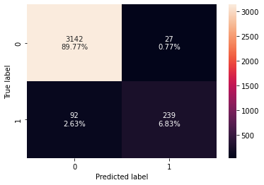

```python
confusion_matrix_sklearn_with_threshold(logreg, X_train_final, y_train)
```

```python
log_reg_model_train_perf_SFS = model_performance_classification_sklearn_with_threshold(
    logreg, X_train_final, y_train
)
print("Training performance:")
log_reg_model_train_perf_SFS
```

```
Training performance:
```

|  | Accuracy | Recall | Precision | F1 |
| --- | --- | --- | --- | --- |
| 0 | 0.966 | 0.722054 | 0.898496 | 0.80067 |

- On test set

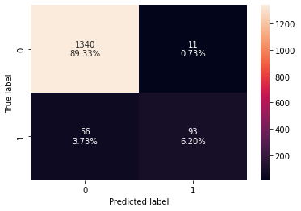

```python
confusion_matrix_sklearn_with_threshold(logreg, X_test_final, y_test)
```

```python
log_reg_model_test_perf_SFS = model_performance_classification_sklearn_with_threshold(
    logreg, X_test_final, y_test
)
print("Test set performance:")
log_reg_model_test_perf_SFS
```

```
Test set performance:
```

|  | Accuracy | Recall | Precision | F1 |
| --- | --- | --- | --- | --- |
| 0 | 0.955333 | 0.624161 | 0.894231 | 0.735178 |

- Model is giving a generalized performance on training and test set.
- With a fewer number of features, the model performance is comparable to the initial logistic regression model.

### Model Performance Summary

```python
# training performance comparison

models_train_comp_df = pd.concat(
    [
        log_reg_model_train_perf.T,
        log_reg_model_train_perf_threshold_auc_roc.T,
        log_reg_model_train_perf_threshold_curve.T,
        log_reg_model_train_perf_SFS.T,
    ],
    axis=1,
)
models_train_comp_df.columns = [
    "Logistic Regression sklearn",
    "Logistic Regression-0.14 Threshold",
    "Logistic Regression-0.35 Threshold",
    "Logistic Regression - SFS",
]
print("Training performance comparison:")
models_train_comp_df
```

```
Training performance comparison:
```

|  | Logistic Regression sklearn | Logistic Regression-0.14 Threshold | Logistic Regression-0.35 Threshold | Logistic Regression - SFS |
| --- | --- | --- | --- | --- |
| Accuracy | 0.965143 | 0.938286 | 0.966857 | 0.966000 |
| Recall | 0.703927 | 0.915408 | 0.815710 | 0.722054 |
| Precision | 0.906615 | 0.617108 | 0.830769 | 0.898496 |
| F1 | 0.792517 | 0.737226 | 0.823171 | 0.800670 |

```python
# testing performance comparison

models_test_comp_df = pd.concat(
    [
        log_reg_model_test_perf.T,
        log_reg_model_test_perf_threshold_auc_roc.T,
        log_reg_model_test_perf_threshold_curve.T,
        log_reg_model_test_perf_SFS.T,

    ],
    axis=1,
)
models_test_comp_df.columns = [
    "Logistic Regression sklearn",
    "Logistic Regression-0.14 Threshold",
    "Logistic Regression-0.35 Threshold",
    "Logistic Regression - SFS",
]
print("Test set performance comparison:")
models_test_comp_df
```

```
Test set performance comparison:
```

|  | Logistic Regression sklearn | Logistic Regression-0.14 Threshold | Logistic Regression-0.35 Threshold | Logistic Regression - SFS |
| --- | --- | --- | --- | --- |
| Accuracy | 0.950000 | 0.918667 | 0.953333 | 0.955333 |
| Recall | 0.583893 | 0.812081 | 0.711409 | 0.624161 |
| Precision | 0.870000 | 0.562791 | 0.796992 | 0.894231 |
| F1 | 0.698795 | 0.664835 | 0.751773 | 0.735178 |

### Observation

- We built a model which has a better F1 score than the initial model but with only 48 features.
- We found that 'Income', 'CD_Account', 'CreditCard', Family, Zip_Section and Zip_Area etc. are important features.

## Build Decision Tree Model

- We will build our model using the DecisionTreeClassifier function. Using default 'gini' criteria to split.
- If the frequency of class A is 10% and the frequency of class B is 90%, then class B will become the dominant class and the decision tree will become biased toward the dominant classes.
- In this case, we can pass a dictionary {0:0.10,1:0.90} to the model to specify the weight of each class and the decision tree will give more weightage to class 1.
- class_weight is a hyperparameter for the decision tree classifier.

```python
##  Function to calculate recall score
def get_recall_score(model, predictors, target):
    """
    model: classifier
    predictors: independent variables
    target: dependent variable

    """
    prediction = model.predict(predictors)
    return recall_score(target, prediction)
```

```python
def confusion_matrix_sklearn(model, predictors, target):
    """
    To plot the confusion_matrix with percentages

    model: classifier
    predictors: independent variables
    target: dependent variable
    """
    y_pred = model.predict(predictors)
    cm = confusion_matrix(target, y_pred)
    labels = np.asarray(
        [
            ["{0:0.0f}".format(item) + "\n{0:.2%}".format(item / cm.flatten().sum())]
            for item in cm.flatten()
        ]
    ).reshape(2, 2)

    plt.figure(figsize=(6, 4))
    sns.heatmap(cm, annot=labels, fmt="")
    plt.ylabel("True label")
    plt.xlabel("Predicted label")
```

```python
model = DecisionTreeClassifier(
    criterion="gini", class_weight={0: 0.10, 1: 0.90}, random_state=1
)
```

```python
model.fit(X_train, y_train)
```

```
DecisionTreeClassifier(class_weight={0: 0.1, 1: 0.9}, random_state=1)
```

#### Checking model performance on training set

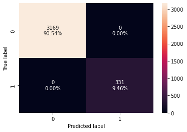

```python
confusion_matrix_sklearn(model, X_train, y_train)
```

```python
decision_tree_perf_train = get_recall_score(model, X_train, y_train)

print("Recall Score:", decision_tree_perf_train)
```

```
Recall Score: 1.0
```

- Model is able to perfectly classify all the data points on the training set.
- 0 errors on the training set, each sample has been classified correctly.
- As we know a decision tree will continue to grow and classify each data point correctly if no restrictions are applied as the trees will learn all the patterns in the training set.
- This generally leads to overfitting of the model as Decision Tree will perform well on the training set but will fail to replicate the performance on the test set.

#### Checking model performance on test set

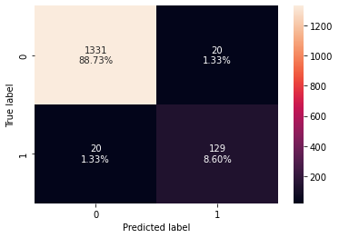

```python
confusion_matrix_sklearn(model, X_test, y_test)
```

```python
decision_tree_perf_test = get_recall_score(model, X_test, y_test)
print("Recall Score:", decision_tree_perf_test)
```

```
Recall Score: 0.8657718120805369
```

- There is a disparity in performance of model on training set and test set, which suggests that the model could be overfiiting.

## Visualizing the Decision Tree

```python
## creating a list of column names
feature_names = X_train.columns.to_list()
```

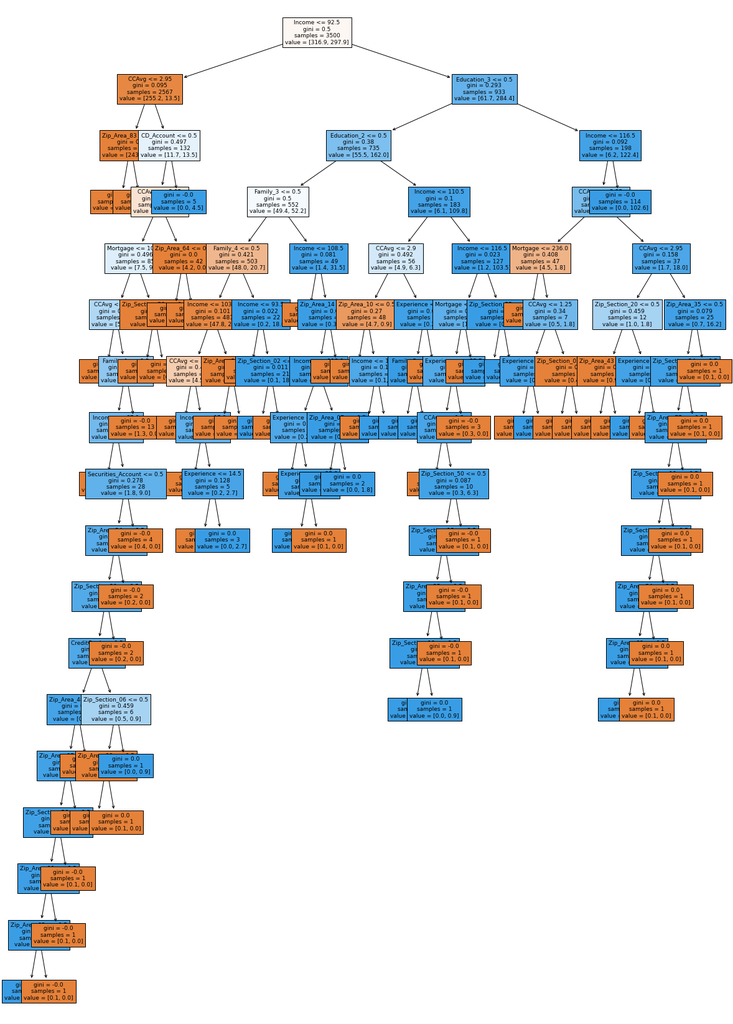

```python
plt.figure(figsize=(20, 30))
out = tree.plot_tree(
    model,
    feature_names=feature_names,
    filled=True,
    fontsize=9,
    node_ids=False,
    class_names=None,
)
# below code will add arrows to the decision tree split if they are missing
for o in out:
    arrow = o.arrow_patch
    if arrow is not None:
        arrow.set_edgecolor("black")
        arrow.set_linewidth(1)
plt.show()
```

```python
# importance of features in the tree building ( The importance of a feature is computed as the
# (normalized) total reduction of the criterion brought by that feature. It is also known as the Gini importance )

print(
    pd.DataFrame(
        model.feature_importances_, columns=["Imp"], index=X_train.columns
    ).sort_values(by="Imp", ascending=False)
)
```

```
                             Imp
Income              6.258190e-01
CCAvg               9.034690e-02
Family_4            8.083925e-02
Education_2         6.628501e-02
Family_3            6.237187e-02
Education_3         2.254324e-02
Mortgage            1.242866e-02
CD_Account          7.690498e-03
Experience          6.480891e-03
Zip_Section_20      5.235503e-03
Zip_Area_10         4.333072e-03
Zip_Section_06      2.093272e-03
Securities_Account  1.878577e-03
Zip_Area_24         9.945408e-04
CreditCard          7.010026e-04
Zip_Section_02      6.476421e-04
Zip_Area_60         6.472447e-04
Zip_Area_92         6.432981e-04
Zip_Area_25         6.410644e-04
Zip_Area_14         6.410263e-04
Zip_Area_54         6.393515e-04
Zip_Area_11         6.277970e-04
Zip_Section_19      6.239921e-04
Zip_Section_13      6.213394e-04
Zip_Area_77         6.165192e-04
Zip_Section_56      6.128494e-04
Zip_Section_24      6.091797e-04
Zip_Section_50      6.025109e-04
Zip_Area_35         6.019704e-04
Zip_Area_07         5.984294e-04
Zip_Area_48         5.845125e-04
Zip_Area_83         1.144363e-14
Zip_Area_64         4.843523e-16
Zip_Area_80         1.095739e-16
Zip_Section_55      1.054166e-16
Family_2            5.856476e-18
Zip_Area_43         1.952159e-18
Zip_Area_66         7.230217e-19
Zip_Area_75         0.000000e+00
```

[output cut: 110 more lines]

```
Zip_Area_02         0.000000e+00
Zip_Section_66      0.000000e+00
Zip_Section_61      0.000000e+00
Zip_Section_60      0.000000e+00
Zip_Section_59      0.000000e+00
Zip_Section_58      0.000000e+00
Zip_Section_57      0.000000e+00
Zip_Section_54      0.000000e+00
Zip_Section_53      0.000000e+00
Zip_Section_52      0.000000e+00
Zip_Section_51      0.000000e+00
Zip_Section_49      0.000000e+00
Zip_Section_48      0.000000e+00
Zip_Section_47      0.000000e+00
Zip_Area_99         0.000000e+00
```

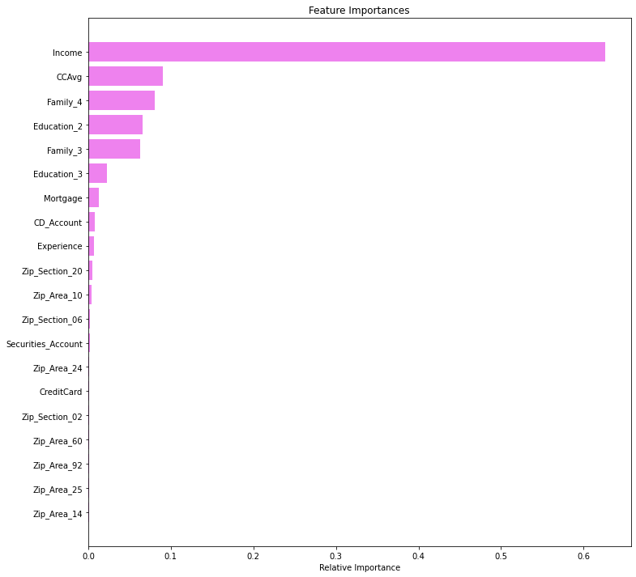

```python
importances = model.feature_importances_
indices = np.argsort(importances)[-20:] # Restrict to Top 20 Important variables

plt.figure(figsize=(12, 12))
plt.title("Feature Importances")
plt.barh(range(len(indices)), importances[indices], color="violet", align="center")
plt.yticks(range(len(indices)), [feature_names[i] for i in indices])
plt.xlabel("Relative Importance")
plt.show()
```

- According to the decision tree model, Income is the most important variable for predicting the Personal_Loan.
- The important variables are similar to that from the Logistic Regression Model
- The difference is that CCAvg (Average spending on credit card per month) was not featured in the Logistic Regression Model

### Reducing over fitting

#### Using GridSearch for Hyperparameter tuning of our tree model

- Hyperparameter tuning is also tricky in the sense that there is no direct way to calculate how a change in the hyperparameter value will reduce the loss of your model, so we usually resort to experimentation. i.e we'll use Grid search
- Grid search is a tuning technique that attempts to compute the optimum values of hyperparameters.
- It is an exhaustive search that is performed on a the specific parameter values of a model.
- The parameters of the estimator/model used to apply these methods are optimized by cross-validated grid-search over a parameter grid.

```python
# Choose the type of classifier.
estimator = DecisionTreeClassifier(random_state=1, class_weight={0: 0.10, 1: 0.90})

# Grid of parameters to choose from
parameters = {
    "max_depth": [5, 10, 15, None],
    "criterion": ["entropy", "gini"],
    "splitter": ["best", "random"],
    "min_impurity_decrease": [0.00001, 0.0001, 0.01],
}

# Type of scoring used to compare parameter combinations
scorer = make_scorer(recall_score)

# Run the grid search
grid_obj = GridSearchCV(estimator, parameters, scoring=scorer, cv=5)
grid_obj = grid_obj.fit(X_train, y_train)

# Set the clf to the best combination of parameters
estimator = grid_obj.best_estimator_

# Fit the best algorithm to the data.
estimator.fit(X_train, y_train)
```

```
DecisionTreeClassifier(class_weight={0: 0.1, 1: 0.9}, max_depth=5,
                       min_impurity_decrease=0.01, random_state=1)
```

#### Checking performance on training set

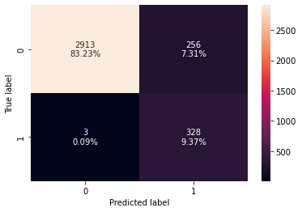

```python
confusion_matrix_sklearn(estimator, X_train, y_train)
```

```python
decision_tree_tune_perf_train = get_recall_score(estimator, X_train, y_train)
print("Recall Score:", decision_tree_tune_perf_train)
```

```
Recall Score: 0.9909365558912386
```

#### Checking performance on test set

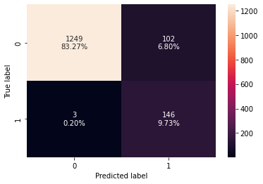

```python
confusion_matrix_sklearn(estimator, X_test, y_test)
```

```python
decision_tree_tune_perf_test = get_recall_score(estimator, X_test, y_test)
print("Recall Score:", decision_tree_tune_perf_test)
```

```
Recall Score: 0.9798657718120806
```

- The model is giving a generalized result now.

## Visualizing the Decision Tree

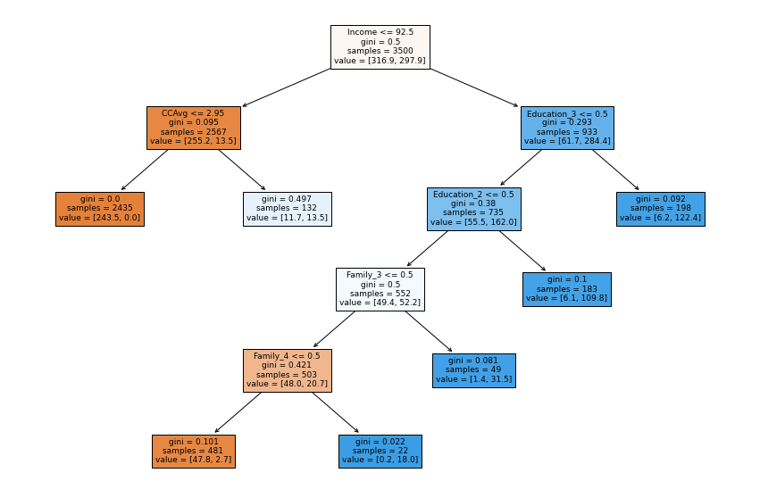

```python
plt.figure(figsize=(15, 10))
out = tree.plot_tree(
    estimator,
    feature_names=feature_names,
    filled=True,
    fontsize=9,
    node_ids=False,
    class_names=None,
)
for o in out:
    arrow = o.arrow_patch
    if arrow is not None:
        arrow.set_edgecolor("black")
        arrow.set_linewidth(1)
plt.show()
```

```python
# importance of features in the tree building ( The importance of a feature is computed as the
# (normalized) total reduction of the 'criterion' brought by that feature. It is also known as the Gini importance )

print(
    pd.DataFrame(
        estimator.feature_importances_, columns=["Imp"], index=X_train.columns
    ).sort_values(by="Imp", ascending=False)
)

# Here we will see that importance of features has increased
```

```
                         Imp
Income              0.684586
Family_4            0.089037
Education_2         0.077395
Family_3            0.072826
CCAvg               0.049835
Education_3         0.026322
Zip_Area_48         0.000000
Zip_Area_40         0.000000
Zip_Area_41         0.000000
Zip_Area_42         0.000000
Zip_Area_43         0.000000
Zip_Area_44         0.000000
Zip_Area_45         0.000000
Zip_Area_46         0.000000
Zip_Area_47         0.000000
Experience          0.000000
Zip_Area_49         0.000000
Zip_Area_50         0.000000
Zip_Area_38         0.000000
Zip_Area_51         0.000000
Zip_Area_52         0.000000
Zip_Area_53         0.000000
Zip_Area_54         0.000000
Zip_Area_55         0.000000
Zip_Area_39         0.000000
Zip_Area_34         0.000000
Zip_Area_37         0.000000
Zip_Area_27         0.000000
Zip_Area_20         0.000000
Zip_Area_21         0.000000
Zip_Area_22         0.000000
Zip_Area_23         0.000000
Zip_Area_24         0.000000
Zip_Area_25         0.000000
Zip_Area_26         0.000000
Zip_Area_28         0.000000
Zip_Area_36         0.000000
Zip_Area_29         0.000000
Zip_Area_30         0.000000
```

[output cut: 110 more lines]

```
Zip_Section_42      0.000000
Zip_Section_43      0.000000
Zip_Section_44      0.000000
Zip_Section_45      0.000000
Zip_Section_46      0.000000
Zip_Section_47      0.000000
Zip_Section_48      0.000000
Zip_Section_49      0.000000
Zip_Section_50      0.000000
Zip_Section_51      0.000000
Zip_Section_52      0.000000
Zip_Section_53      0.000000
Zip_Section_54      0.000000
Zip_Section_55      0.000000
Zip_Area_99         0.000000
```

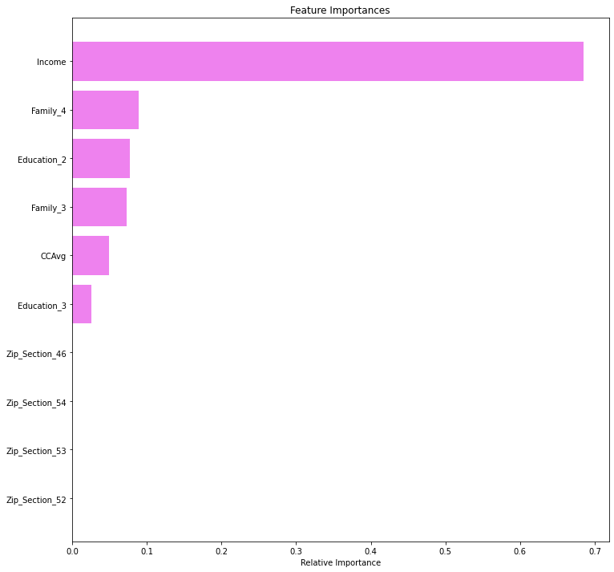

```python
importances = estimator.feature_importances_
indices = np.argsort(importances)[-10:]

plt.figure(figsize=(12, 12))
plt.title("Feature Importances")
plt.barh(range(len(indices)), importances[indices], color="violet", align="center")
plt.yticks(range(len(indices)), [feature_names[i] for i in indices])
plt.xlabel("Relative Importance")
plt.show()
```

- In tuned decision tree Income is the most important feature followed by Family_4.

## Cost Complexity Pruning

The `DecisionTreeClassifier` provides parameters such as `min_samples_leaf` and `max_depth` to prevent a tree from overfiting. Cost complexity pruning provides another option to control the size of a tree. In `DecisionTreeClassifier`, this pruning technique is parameterized by the cost complexity parameter, `ccp_alpha`. Greater values of `ccp_alpha` increase the number of nodes pruned. Here we only show the effect of `ccp_alpha` on regularizing the trees and how to choose a `ccp_alpha` based on validation scores.

## Total impurity of leaves vs effective alphas of pruned tree

Minimal cost complexity pruning recursively finds the node with the "weakest link". The weakest link is characterized by an effective alpha, where the nodes with the smallest effective alpha are pruned first. To get an idea of what values of `ccp_alpha` could be appropriate, scikit-learn provides `DecisionTreeClassifier.cost_complexity_pruning_path` that returns the effective alphas and the corresponding total leaf impurities at each step of the pruning process. As alpha increases, more of the tree is pruned, which increases the total impurity of its leaves.

```python
clf = DecisionTreeClassifier(random_state=1, class_weight={0: 0.10, 1: 0.90})
path = clf.cost_complexity_pruning_path(X_train, y_train)
ccp_alphas, impurities = path.ccp_alphas, path.impurities
```

```python
pd.DataFrame(path)
```

|  | ccp_alphas | impurities |
| --- | --- | --- |
| 0 | 0.000000e+00 | -1.096878e-15 |
| 1 | 3.611656e-19 | -1.096517e-15 |
| 2 | 9.751471e-19 | -1.095542e-15 |
| 3 | 1.011264e-18 | -1.094530e-15 |
| 4 | 2.275343e-18 | -1.092255e-15 |
| 5 | 2.925441e-18 | -1.089330e-15 |
| 6 | 1.072662e-17 | -1.078603e-15 |
| 7 | 2.275343e-17 | -1.055850e-15 |
| 8 | 5.265794e-17 | -1.003192e-15 |
| 9 | 5.473465e-17 | -9.484570e-16 |
| 10 | 2.419448e-16 | -7.065121e-16 |
| 11 | 5.716348e-15 | 5.009836e-15 |
| 12 | 2.155044e-04 | 6.465132e-04 |
| 13 | 2.927781e-04 | 9.392914e-04 |
| 14 | 3.063957e-04 | 2.471270e-03 |
| 15 | 3.081875e-04 | 2.779458e-03 |
| 16 | 3.081875e-04 | 3.087645e-03 |
| 17 | 3.105223e-04 | 4.019212e-03 |
| 18 | 3.118347e-04 | 6.202055e-03 |
| 19 | 3.202070e-04 | 6.522262e-03 |
| 20 | 3.217342e-04 | 7.165730e-03 |
| 21 | 5.753795e-04 | 7.741110e-03 |
| 22 | 6.023164e-04 | 1.015038e-02 |
| 23 | 6.057479e-04 | 1.075612e-02 |
| 24 | 6.273817e-04 | 1.138350e-02 |
| 25 | 7.666497e-04 | 1.215015e-02 |
| 26 | 7.840069e-04 | 1.450218e-02 |
| 27 | 9.383915e-04 | 1.544057e-02 |
| 28 | 9.647609e-04 | 1.640533e-02 |
| 29 | 1.280997e-03 | 1.896732e-02 |
| 30 | 1.682633e-03 | 2.064995e-02 |
| 31 | 2.164467e-03 | 2.281442e-02 |
| 32 | 2.208456e-03 | 2.723133e-02 |
| 33 | 2.328917e-03 | 2.956025e-02 |
| 34 | 2.909596e-03 | 3.246985e-02 |
| 35 | 3.240232e-03 | 3.571008e-02 |
| 36 | 3.393805e-03 | 3.910388e-02 |
| 37 | 3.470671e-03 | 4.604523e-02 |
| 38 | 3.841577e-03 | 4.988680e-02 |
| 39 | 4.980603e-03 | 5.984801e-02 |
| 40 | 5.881704e-03 | 6.572971e-02 |
| 41 | 5.974141e-03 | 7.170385e-02 |
| 42 | 2.132036e-02 | 9.302421e-02 |
| 43 | 2.840493e-02 | 2.066439e-01 |
| 44 | 2.928785e-01 | 4.995225e-01 |

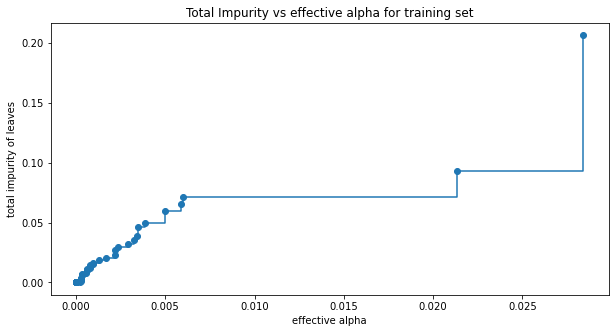

```python
fig, ax = plt.subplots(figsize=(10, 5))
ax.plot(ccp_alphas[:-1], impurities[:-1], marker="o", drawstyle="steps-post")
ax.set_xlabel("effective alpha")
ax.set_ylabel("total impurity of leaves")
ax.set_title("Total Impurity vs effective alpha for training set")
plt.show()
```

Next, we train a decision tree using the effective alphas. The last value in `ccp_alphas` is the alpha value that prunes the whole tree, leaving the tree, `clfs[-1]`, with one node.

```python
clfs = []
for ccp_alpha in ccp_alphas:
    clf = DecisionTreeClassifier(
        random_state=1, ccp_alpha=ccp_alpha, class_weight={0: 0.10, 1: 0.90}
    )
    clf.fit(X_train, y_train)
    clfs.append(clf)
print(
    "Number of nodes in the last tree is: {} with ccp_alpha: {}".format(
        clfs[-1].tree_.node_count, ccp_alphas[-1]
    )
)
```

```
Number of nodes in the last tree is: 1 with ccp_alpha: 0.2928785401980035
```

For the remainder, we remove the last element in `clfs` and `ccp_alphas`, because it is the trivial tree with only one node. Here we show that the number of nodes and tree depth decreases as alpha increases.

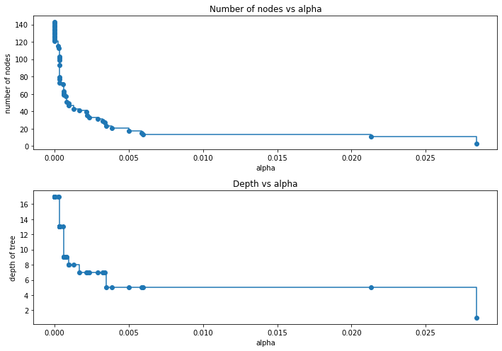

```python
clfs = clfs[:-1]
ccp_alphas = ccp_alphas[:-1]

node_counts = [clf.tree_.node_count for clf in clfs]
depth = [clf.tree_.max_depth for clf in clfs]
fig, ax = plt.subplots(2, 1, figsize=(10, 7))
ax[0].plot(ccp_alphas, node_counts, marker="o", drawstyle="steps-post")
ax[0].set_xlabel("alpha")
ax[0].set_ylabel("number of nodes")
ax[0].set_title("Number of nodes vs alpha")
ax[1].plot(ccp_alphas, depth, marker="o", drawstyle="steps-post")
ax[1].set_xlabel("alpha")
ax[1].set_ylabel("depth of tree")
ax[1].set_title("Depth vs alpha")
fig.tight_layout()
```

```python
recall_train = []
for clf in clfs:
    pred_train = clf.predict(X_train)
    values_train = recall_score(y_train, pred_train)
    recall_train.append(values_train)
```

```python
recall_test = []
for clf in clfs:
    pred_test = clf.predict(X_test)
    values_test = recall_score(y_test, pred_test)
    recall_test.append(values_test)
```

```python
train_scores = [clf.score(X_train, y_train) for clf in clfs]
test_scores = [clf.score(X_test, y_test) for clf in clfs]
```

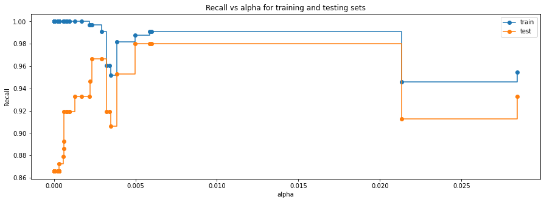

```python
fig, ax = plt.subplots(figsize=(15, 5))
ax.set_xlabel("alpha")
ax.set_ylabel("Recall")
ax.set_title("Recall vs alpha for training and testing sets")
ax.plot(
    ccp_alphas, recall_train, marker="o", label="train", drawstyle="steps-post",
)
ax.plot(ccp_alphas, recall_test, marker="o", label="test", drawstyle="steps-post")
ax.legend()
plt.show()
```

**Maximum value of Recall is at 0.005 alpha which is good**

```python
# creating the model where we get highest train and test recall
index_best_model = np.argmax(recall_test)
best_model = clfs[index_best_model]
print(best_model)
```

```
DecisionTreeClassifier(ccp_alpha=0.004980603234982057,
                       class_weight={0: 0.1, 1: 0.9}, random_state=1)
```

```python
best_model.fit(X_train, y_train)
```

```
DecisionTreeClassifier(ccp_alpha=0.004980603234982057,
                       class_weight={0: 0.1, 1: 0.9}, random_state=1)
```

#### checking performance on training set

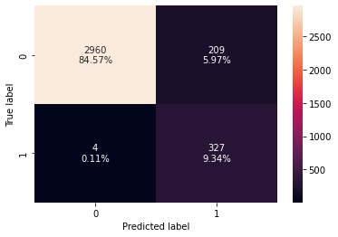

```python
confusion_matrix_sklearn(best_model, X_train, y_train)
```

```python
print("Recall Score:", get_recall_score(best_model, X_train, y_train))
```

```
Recall Score: 0.9879154078549849
```

#### checking performance on test set

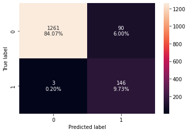

```python
confusion_matrix_sklearn(best_model, X_test, y_test)
```

```python
print("Recall Score:", get_recall_score(best_model, X_test, y_test))
```

```
Recall Score: 0.9798657718120806
```

### Visualizing the Decision Tree

[figure not shown]

```python
plt.figure(figsize=(5, 5))

out = tree.plot_tree(
    best_model,
    feature_names=feature_names,
    filled=True,
    fontsize=9,
    node_ids=False,
    class_names=None,
)
for o in out:
    arrow = o.arrow_patch
    if arrow is not None:
        arrow.set_edgecolor("black")
        arrow.set_linewidth(1)
plt.show()
```

```python
decision_tree_postpruned_perf_train = get_recall_score(best_model, X_train, y_train)
print("Recall Score:", decision_tree_postpruned_perf_train)
```

```
Recall Score: 0.9879154078549849
```

```python
decision_tree_postpruned_perf_test = get_recall_score(best_model, X_test, y_test)
print("Recall Score:", decision_tree_postpruned_perf_test)
```

```
Recall Score: 0.9798657718120806
```

- This model might be giving the highest recall but a buisness would not be able to use it to actually target the potential customers.

```python
# importance of features in the tree building ( The importance of a feature is computed as the
# (normalized) total reduction of the 'criterion' brought by that feature. It is also known as the Gini importance )

print(
    pd.DataFrame(
        best_model.feature_importances_, columns=["Imp"], index=X_train.columns
    ).sort_values(by="Imp", ascending=False)
)
```

```
                         Imp
Income              0.679714
Family_4            0.086636
Education_2         0.075308
Family_3            0.070862
CCAvg               0.061869
Education_3         0.025612
Zip_Area_48         0.000000
Zip_Area_40         0.000000
Zip_Area_41         0.000000
Zip_Area_42         0.000000
Zip_Area_43         0.000000
Zip_Area_44         0.000000
Zip_Area_45         0.000000
Zip_Area_46         0.000000
Zip_Area_47         0.000000
Experience          0.000000
Zip_Area_49         0.000000
Zip_Area_50         0.000000
Zip_Area_38         0.000000
Zip_Area_51         0.000000
Zip_Area_52         0.000000
Zip_Area_53         0.000000
Zip_Area_54         0.000000
Zip_Area_55         0.000000
Zip_Area_39         0.000000
Zip_Area_34         0.000000
Zip_Area_37         0.000000
Zip_Area_27         0.000000
Zip_Area_20         0.000000
Zip_Area_21         0.000000
Zip_Area_22         0.000000
Zip_Area_23         0.000000
Zip_Area_24         0.000000
Zip_Area_25         0.000000
Zip_Area_26         0.000000
Zip_Area_28         0.000000
Zip_Area_36         0.000000
Zip_Area_29         0.000000
Zip_Area_30         0.000000
```

[output cut: 110 more lines]

```
Zip_Section_42      0.000000
Zip_Section_43      0.000000
Zip_Section_44      0.000000
Zip_Section_45      0.000000
Zip_Section_46      0.000000
Zip_Section_47      0.000000
Zip_Section_48      0.000000
Zip_Section_49      0.000000
Zip_Section_50      0.000000
Zip_Section_51      0.000000
Zip_Section_52      0.000000
Zip_Section_53      0.000000
Zip_Section_54      0.000000
Zip_Section_55      0.000000
Zip_Area_99         0.000000
```

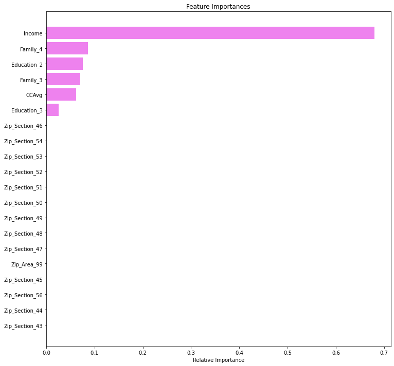

```python
importances = best_model.feature_importances_
indices = np.argsort(importances)[-20:] # Top 20 features

plt.figure(figsize=(12, 12))
plt.title("Feature Importances")
plt.barh(range(len(indices)), importances[indices], color="violet", align="center")
plt.yticks(range(len(indices)), [feature_names[i] for i in indices])
plt.xlabel("Relative Importance")
plt.show()
```

[figure not shown]

```python
importances = best_model.feature_importances_
indices = np.argsort(importances)[:10] # Bottom 10 features

plt.figure(figsize=(12, 12))
plt.title("Feature Importances")
plt.barh(range(len(indices)), importances[indices], color="violet", align="center")
plt.yticks(range(len(indices)), [feature_names[i] for i in indices])
plt.xlabel("Relative Importance")
plt.show()
```

- Our Model has shown that Customer years of Professional Experience does not affect their response to personal loan